# Shiny

De una tabla a una app que otra persona puede usar

Andrés González-Santa Cruz

Reproducibilidad y Comunicación de Resultados · UDP · 2026

# Parte 1 · La idea

5 minutos. Después, una pieza por etapa.

## Ya usó una app Shiny

La encuesta que respondió antes de la primera clase era una app hecha con **Shiny**.

Tenía dos mitades:

- **Lo que se ve**: las preguntas y el botón para enviar.
- **Lo que se calcula**: código R que revisaba y guardaba las respuestas.

Hoy construirá las dos mitades, primero con ejemplos chicos y después con datos reales.

Código de esa encuesta: encuesta/app.R

**Shiny** es un paquete de R para construir aplicaciones web.

- Se escribe en R. No hace falta saber HTML ni JavaScript.
- Convierte un análisis en algo que otra persona puede explorar sin abrir R.

## De una tabla fija a una app

En la clase de Git publicó una tabla. Respondía **una** pregunta, para **un** tramo de edad.

Para ver otro tramo había que cambiar el código, renderizar y subir de nuevo.

En una app, quien visita la página **mueve un control** y el gráfico y la tabla cambian solos. Puede hacer sus propias preguntas.

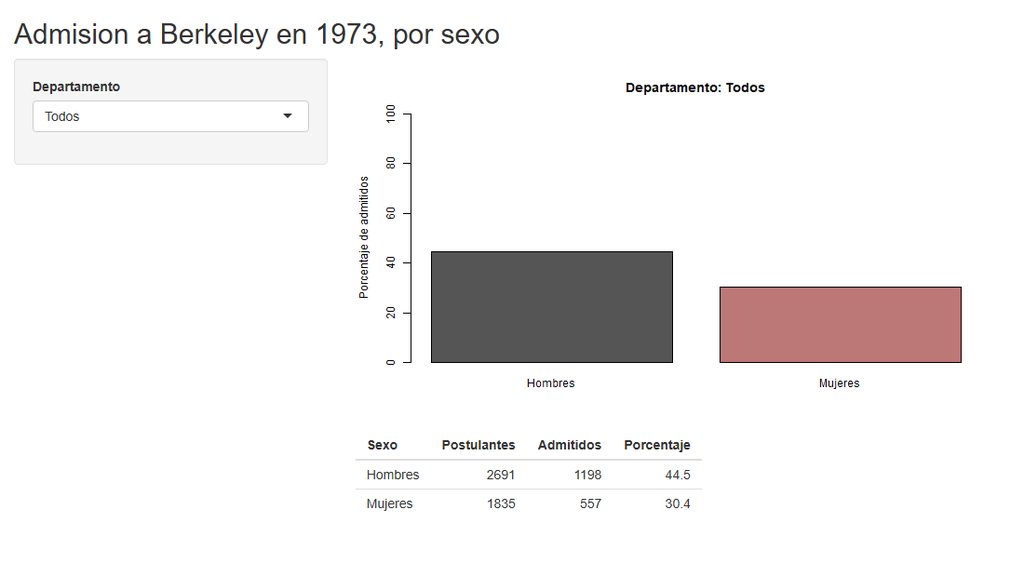

## Toda app tiene dos mitades

**`ui`: lo que se ve**

Un control (*input*) que la persona mueve: un deslizador, un menú.

→

**`server`: lo que se calcula**

Código R que lee el control y prepara un resultado.

→

**`ui`: lo que se ve**

Un resultado (*output*) que aparece en la página: un texto, un gráfico, una tabla.

Al final, una línea las une: `shinyApp(ui, server)`.

Cinco etapas, una pieza cada una: la página, un control, un resultado, un gráfico y el orden en la pantalla.

## Ruta de hoy

1. **Las partes de una app.** Cinco etapas en el navegador, sin instalar nada.
2. **Su app con datos reales.** En RStudio, en un repositorio nuevo.
3. **Publicarla sin servidor.** Primero como un enlace; después en GitHub Pages.
4. **Publicarla con servidor.** En Posit Connect Cloud, desde RStudio.

Cada parte deja algo funcionando. Si una posterior falla, lo anterior sigue en pie.

De la clase de Git solo necesita su cuenta de GitHub y GitHub Desktop. Los datos vienen con R: no hay archivos que copiar.

Un doble clic amplía cualquier parte de la lámina. Otro doble clic la devuelve.

# Parte 2 · Las partes de una app

En el navegador. Etapas 1 a 5.

## Cómo usar el editor vivo

Cada etapa trae un recuadro con dos mitades:

[figure not shown]

- **A la izquierda**, el código. Se puede editar.
- **A la derecha**, la app que ese código produce.
- **El botón ▶**, arriba del código, vuelve a correr la app con sus cambios.

Nada se instala: R corre dentro de su navegador.

**La primera carga tarda.** Puede pasar hasta un minuto con un círculo girando. Las siguientes son más rápidas.

**Si se equivoca**, recargue la página (F5): el código vuelve al original.

**Si el recuadro queda en blanco**, use el enlace *Abrir este editor en una pestaña nueva* que está debajo.

## Etapa 1 · La página: `ui`

`ui` es lo que se ve. Aquí la página solo tiene un texto.

`server` está vacío: todavía no hay nada que calcular.

**Hágalo**

1. Espere a que aparezca la app a la derecha.
2. Cambie el texto entre comillas por su nombre.
3. Presione ▶.

**¿Funcionó?** La app muestra su nombre.

```r
library(shiny)
# ui: lo que se ve. Aqui, solo un texto
ui <- fluidPage(
  "Hola, soy una app"
)
# server: lo que se calcula. Todavia nada
server <- function(input, output) {
}
# La linea que une las dos mitades
shinyApp(ui, server)
```

## Etapa 2 · Un control: `input`

Un control es una pieza de `ui` que la persona puede mover. Este es un deslizador.

Lleva un **nombre interno** (`"edad"`), una etiqueta y sus valores.

**Hágalo**

1. Mueva el deslizador. No pasa nada más: nadie lo está escuchando.
2. Cambie `value = 30` por `value = 50` y presione ▶.

**¿Funcionó?** El deslizador parte en 50.

```r
library(shiny)
ui <- fluidPage(
  titlePanel("Mi primera app"),
  # Un control: nombre interno, etiqueta y valores
  sliderInput("edad", "Elija una edad", min = 18, max = 100, value = 30)
)
# Nadie escucha el control todavia
server <- function(input, output) {
}
shinyApp(ui, server)
```

## Etapa 3 · Un resultado: `output`

Ahora `server` escucha. Lee el control con `input$edad` y escribe un resultado en `output$mensaje`.

En `ui`, `textOutput("mensaje")` reserva el lugar donde aparece.

**Hágalo**

1. Mueva el deslizador: el texto cambia solo.
2. En `ui`, cambie `"mensaje"` por `"aviso"` y presione ▶. El texto desaparece.
3. Arréglelo: en `server` escriba `output$aviso`.

**La idea:** el nombre debe ser el mismo en las dos mitades.

```r
library(shiny)
ui <- fluidPage(
  titlePanel("Mi primera app"),
  sliderInput("edad", "Elija una edad", min = 18, max = 100, value = 30),
  # El lugar donde aparece el resultado llamado "mensaje"
  textOutput("mensaje")
)
server <- function(input, output) {
  # Lee el control (input$edad) y escribe el resultado (output$mensaje)
  output$mensaje <- renderText({
    paste("Edad elegida:", input$edad)
  })
}
shinyApp(ui, server)
```

## Etapa 4 · Un gráfico que responde

Cada resultado tiene su pareja: `plotOutput` en `ui` y `renderPlot` en `server`. Para una tabla, `tableOutput` y `renderTable`.

Dentro de `renderPlot` va código de gráfico como el que ya conoce.

**Hágalo**

1. Mueva el deslizador.
2. Cambie `"gray"` por `"tomato"` y presione ▶.

**¿Funcionó?** El histograma cambia con el deslizador y ahora es rojo.

```r
library(shiny)
ui <- fluidPage(
  titlePanel("Un grafico que responde"),
  sliderInput("n", "Cantidad de personas", min = 10, max = 500, value = 50),
  # El lugar del grafico
  plotOutput("grafico")
)
server <- function(input, output) {
  # renderPlot vuelve a dibujar cada vez que cambia input$n
  output$grafico <- renderPlot({
    edades <- rnorm(input$n, mean = 40, sd = 12)
    hist(edades, col = "gray", border = "white", main = "Edades simuladas")
  })
}
shinyApp(ui, server)
```

## Etapa 5 · Ordenar la pantalla y conectar un control

`sidebarLayout` separa la página: los controles a un lado (`sidebarPanel`) y los resultados al otro (`mainPanel`).

Hay un control nuevo, **Color**, pero no hace nada.

**Hágalo**

1. Cambie el color en el menú: el gráfico no reacciona.
2. Conéctelo: en `server`, cambie `col = "gray"` por `col = input$color`.
3. Presione ▶ y pruebe el menú.

**¿Funcionó?** El histograma toma el color elegido.

```r
library(shiny)
ui <- fluidPage(
  titlePanel("Controles a un lado, resultados al otro"),
  sidebarLayout(
    # A un lado, los controles
    sidebarPanel(
      sliderInput("n", "Cantidad de personas", min = 10, max = 500, value = 50),
      selectInput("color", "Color", choices = c("gray", "tomato", "steelblue"))
    ),
    # Al otro, los resultados
    mainPanel(
      plotOutput("grafico")
    )
  )
)
server <- function(input, output) {
  output$grafico <- renderPlot({
    edades <- rnorm(input$n, mean = 40, sd = 12)
    # El color esta fijo: falta conectarlo con input$color
    hist(edades, col = "gray", border = "white", main = "Edades simuladas")
  })
}
shinyApp(ui, server)
```

## Antes de seguir: ¿`ui` o `server`?

¿En qué mitad va cada línea?

1. `sliderInput("edad", "Rango de edad", min = 18, max = 100, value = 30)`
2. `output$tabla <- renderTable({ ... })`
3. `tableOutput("tabla")`
4. `paste("Edad elegida:", input$edad)`

**1 y 3 van en `ui`**: son cosas que se ven, un control y el lugar de un resultado. **2 y 4 van en `server`**: son cálculos. Leen `input$…` y escriben `output$…`.

| Pieza | Mitad | Ejemplo |
| --- | --- | --- |
| Control | `ui` | `sliderInput("edad", …)` |
| Lugar del resultado | `ui` | `plotOutput("grafico")` |
| Cálculo del resultado | `server` | `output$grafico <- renderPlot({ … })` |
| Unión | al final | `shinyApp(ui, server)` |

# Parte 3 · Su app con datos reales

En RStudio, en un repositorio nuevo. Pasos 1 a 6.

## Paso 1 · Instale los paquetes

En la consola de RStudio:

```r
install.packages(c("shiny", "rsconnect"))
```

- `shiny` construye la app.
- `rsconnect` la prepara para Connect Cloud (parte 5).

**¿Error con `rlang` o `00LOCK`?** Pasa con R 4.4. Instale `rsconnect` en su versión binaria:

```r
renv::install("rsconnect", type = "binary")
```

**¿Cómo sé que funcionó?** La instalación termina sin la palabra `Error`. Después, `library(shiny)` no responde nada.

**Ojo.** Si arriba a la derecha de RStudio aparece el nombre de un proyecto, ciérrelo antes: **File → Close Project**.

**Aviso de Rtools.** Ignórelo: los paquetes se instalan igual.

## Paso 2 · Cree un repositorio para la app

1. En GitHub Desktop: **File → New repository…**

[figure not shown]

2. **Name**: `shiny-` más su nombre. Por ejemplo, `shiny-maria`.
3. Marque **Initialize this repository with a README** y presione **Create repository**.

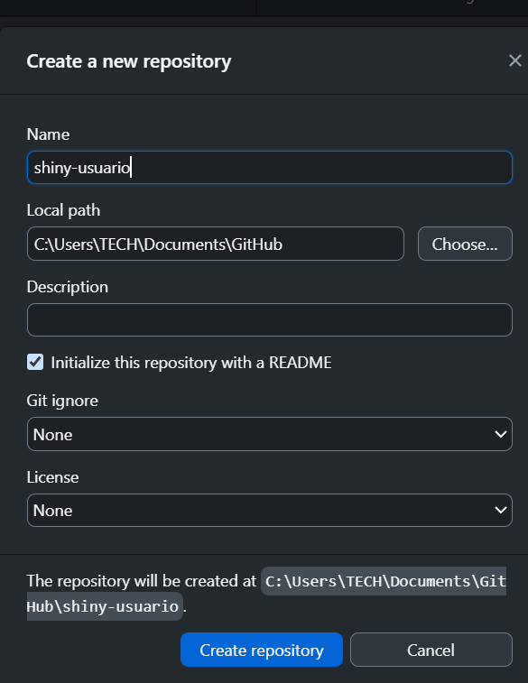

4. Con **Show in Explorer** vea dónde quedó la carpeta: la necesita en el punto siguiente.

[figure not shown]

5. En RStudio: **File → New Project… → Existing Directory**.

[figure not shown]

   Con **Browse…** elija la carpeta de su repositorio y presione **Create Project**.

[figure not shown]

6. **File → New File → R Script**

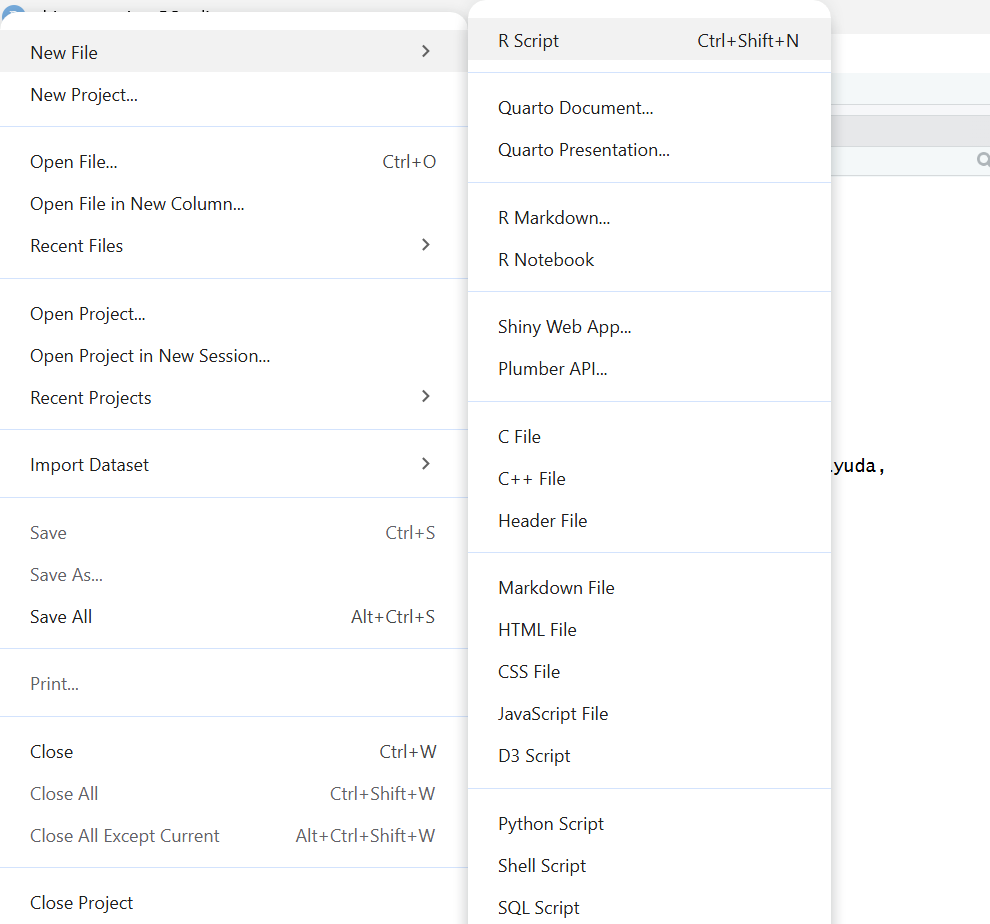

   y pegue el guion de la lámina siguiente.
7. **File → Save As…**

[figure not shown]

   Guárdelo como `00estructura_shiny.R`: la ventana ya abre en su repositorio.
8. Presione **Source**.

[figure not shown]

**¿Cómo sé que funcionó?** La consola dice `Listo`. El repositorio tiene una carpeta `app` vacía, `_doc`, `DESCRIPTION`, `README.md`, `renv.lock` y el archivo del proyecto (`.Rproj`).

**¿Para qué el proyecto?** Al abrirlo, R trabaja dentro de la carpeta del repositorio. No hay que decirle dónde está cada archivo.

**Ojo.** Sin tildes, sin ñ y sin espacios en el nombre del repositorio. Si sale `Error`, lea el mensaje: dice qué hacer.

## El guion del paso 2

```r
# 00estructura_shiny.R: ordena el repositorio de su app como un compendio (paso 2)
# 1. PAQUETES QUE USA LA APP (los del paso 1; no hay que editar nada)
paquetes <- c("shiny", "rsconnect")
# 2. COMPROBAR antes de escribir archivos
if (nzchar(Sys.getenv("RENV_PROJECT")))      # hay un proyecto con renv abierto
  stop("Cierre el proyecto: File > Close Project")
if (!dir.exists(".git"))                     # .git marca la carpeta del repositorio
  stop("Abra el proyecto de su repositorio: File > Open Project")
faltan <- setdiff(paquetes, rownames(installed.packages()))   # paquetes sin instalar
if (length(faltan) > 0) stop("Primero instale (paso 1): ", paste(faltan, collapse = ", "))
# 3. CARPETAS
dir.create("app", showWarnings = FALSE)      # la app vive sola aqui: es lo que se publica
dir.create("_doc", showWarnings = FALSE)     # documentacion del entorno
# 4. DESCRIPTION: autoria y paquetes (repositorio publico: sin datos personales)
writeLines(c(
  "Type: Project",
  "Title: App Shiny del curso Reproducibilidad (UDP 2026)",
  'Authors@R: person("SU-USUARIO", role = c("aut", "cre"))',   # marcador: no identifica a nadie
  paste("Imports:", paste(paquetes, collapse = ", "))
), "DESCRIPTION")
# 5. renv.lock: versiones de R y de cada paquete, como en la clase 1
options(renv.consent = TRUE)                 # renv no pregunta la primera vez
renv::snapshot(type = "explicit",            # registra lo que dice Imports en DESCRIPTION
               library = .libPaths(),        # lee los paquetes ya instalados: no activa renv
               prompt = FALSE)
# 6. ENTORNO: sistema operativo, version de R e idioma del computador
writeLines(capture.output(sessionInfo()), "_doc/entorno.txt")
# 7. README: solo si sigue como lo creo GitHub Desktop (no borra lo que usted escribio)
if (!file.exists("README.md") || length(readLines("README.md")) < 3) {
  writeLines(c(
    paste("#", basename(getwd())), "",            # nombre del repositorio
    "App Shiny del curso Reproducibilidad (UDP 2026).", "",
    "| Archivo | Que contiene |",
    "| --- | --- |",
    "| `app/app.R` | La app |",
    "| `app/manifest.json` | Version de R y paquetes para Connect Cloud (paso 12) |",
    "| `renv.lock` | Version de R y paquetes del computador donde se creo |",
    "| `DESCRIPTION` | Autoria y paquetes |",
    "| `_doc/entorno.txt` | Sistema operativo e idioma |"
  ), "README.md")
}
# 8. COMPROBAR que todo quedo
stopifnot(dir.exists("app"), file.exists("DESCRIPTION", "renv.lock", "README.md", "_doc/entorno.txt"))
message("Listo. Siga con el paso 3: guarde app.R dentro de la carpeta app.")
```

Copie todo con el botón que aparece arriba a la derecha del código. No hay que cambiar nada.

**Lo que deja en su repositorio:**

- `app/`: donde vivirá la app, sola;
- `DESCRIPTION`: qué paquetes usa (el autor es el marcador `SU-USUARIO`);
- `renv.lock` y `_doc/entorno.txt`: con qué versiones y en qué computador;
- `README.md`: qué es cada archivo.

Es el compendio de la primera clase, en chico. Esta vez `renv.lock` solo **registra** las versiones: no cambia dónde R busca los paquetes.

## Paso 3 · Escriba la app

1. En RStudio: **File → New File → R Script**.

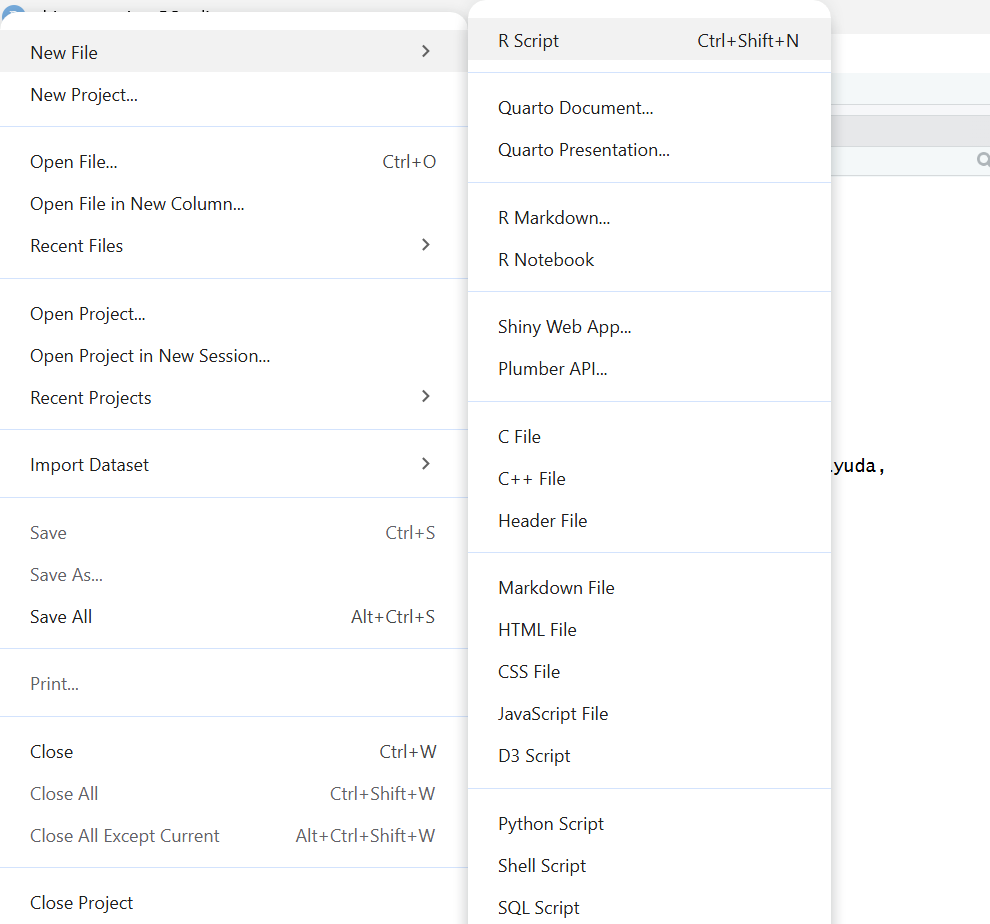

2. Pegue el código de la lámina siguiente.
3. **File → Save As…**,

[figure not shown]

   entre a la carpeta `app` de su repositorio

[figure not shown]

   y guárdelo como `app.R`.

[figure not shown]

Una app vive en su propia carpeta. Esta no necesita nada más: los datos vienen con R.

**¿Cómo sé que funcionó?** En RStudio, arriba del código, aparece el botón **Run App**.

[figure not shown]

**Ojo.** El archivo debe llamarse exactamente `app.R`.

## El código de su app

```r
library(shiny)
# DATOS: postulaciones a la Universidad de Berkeley en 1973, por resultado,
# sexo y departamento. Vienen con R: no hay que cargar ningun archivo.
datos <- UCBAdmissions
# UI: lo que se ve
ui <- fluidPage(
  titlePanel("Admision a Berkeley en 1973, por sexo"),
  sidebarLayout(
    # Un control: el menu de departamentos
    sidebarPanel(
      selectInput("depto", "Departamento", choices = c("Todos", LETTERS[1:6]))
    ),
    # Dos resultados: un grafico y una tabla
    mainPanel(
      plotOutput("grafico"),
      tableOutput("tabla")
    )
  )
)
# SERVER: lo que se calcula
server <- function(input, output) {
  # Postulantes por resultado y sexo, en el departamento elegido.
  # Es reactive(): se recalcula solo cuando cambia el menu
  conteo <- reactive({
    if (input$depto == "Todos") {
      apply(datos, c(1, 2), sum)
    } else {
      datos[, , input$depto]
    }
  })
  # Porcentaje de admitidos en cada sexo; lo usan el grafico y la tabla
  porcentaje <- reactive({
    100 * conteo()["Admitted", ] / colSums(conteo())
  })
  output$grafico <- renderPlot({
    barplot(porcentaje(), names.arg = c("Hombres", "Mujeres"),
            ylim = c(0, 100), ylab = "Porcentaje de admitidos",
            col = c("#555555", "#bc7777"),
            main = paste("Departamento:", input$depto))
  })
  output$tabla <- renderTable({
    data.frame(Sexo = c("Hombres", "Mujeres"),
               Postulantes = as.integer(colSums(conteo())),
               Admitidos = as.integer(conteo()["Admitted", ]),
               Porcentaje = porcentaje())
  }, digits = 1)
}
# La linea que une las dos mitades
shinyApp(ui, server)
```

Copie todo con el botón que aparece arriba a la derecha del código.

**Ya conoce casi todo:**

- un control en `sidebarPanel`;
- un gráfico y una tabla en `mainPanel`;
- `renderPlot` y `renderTable` en `server`.

**Lo nuevo: `reactive()`.** El gráfico y la tabla usan el mismo cálculo. Se escribe una vez, se le pone nombre (`porcentaje`) y se usa con paréntesis: `porcentaje()`.

El código no tiene tildes ni ñ, tampoco en los textos: en algunos computadores se ven como signos raros.

## Paso 4 · Córrala y hágale una pregunta a los datos

1. Con `app.R` abierto, presione **Run App**.

[figure not shown]

   Se abre una ventana con la app.
2. Deje *Todos*. ¿Admitían más a los hombres?

[figure not shown]

3. Ahora elija los departamentos, uno por uno. ¿Se mantiene?
4. Para detenerla, cierre la ventana

[figure not shown]

   o presione el botón rojo **Stop** de la consola.

[figure not shown]

Mientras la app corre, la consola dice `Listening on http://127.0.0.1:…` y no acepta otros comandos. Es lo normal.

**¿Cómo sé que funcionó?** Con *Todos*, la tabla dice **44.5** para hombres y **30.4** para mujeres. Con el departamento *A*, **62.1** y **82.4**.

Una tabla fija habría mostrado solo el total. La app deja ver que la diferencia cambia, y hasta se invierte, dentro de cada departamento.

## Paso 5 · Hágala suya

Cambie dos cosas en `app.R`:

1. El título: dentro de `titlePanel(…)` agregue su nombre, sin tildes.
2. Un color del gráfico: `"#bc7777"` por `"steelblue"`.

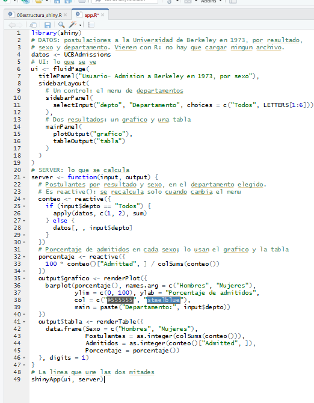

Guarde y presione **Run App** otra vez.

**¿Cómo sé que funcionó?** La app abre con su nombre en el título y una barra azul.

**Ojo.** Cada paréntesis que se abre se cierra, y cada pieza de `ui` termina en coma, salvo la última. Es el error más común.

## Paso 6 · Guarde y suba (commit y push)

1. En GitHub Desktop, en **Changes**, aparecen `app/app.R` y los archivos del paso 2. Deje todos marcados.

[figure not shown]

2. Mensaje: `Agrega app Shiny`. Presione **Commit to main**.
3. Presione **Publish repository**.
4. **Desmarque** *Keep this code private* y presione **Publish repository**.

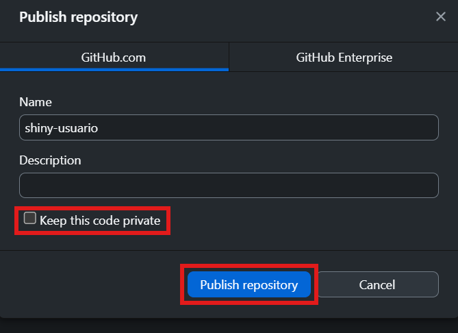

**¿Cómo sé que funcionó?** Con **Repository → View on GitHub**, su repositorio muestra la carpeta `app` con `app.R` adentro.

Su app ya está guardada y respaldada, pero nadie más puede usarla: solo corre en su computador. Para eso son las partes 4 y 5.

# Parte 4 · Publicar sin servidor

Con shinylive: primero un enlace, después GitHub Pages. Pasos 7 a 9.

## Shinylive: R viaja al navegador

Una app Shiny necesita un computador con R que la mantenga corriendo. Una página web común solo entrega archivos: no corre R.

**Shinylive** empaqueta R, Shiny y su app. Quien visita la página los descarga y R corre **en su navegador**.

Es lo que usó en las etapas 1 a 5.

**A favor:** gratis, sin servidor y sin cuentas nuevas.

**En contra:** la primera carga es lenta, y los datos viajan completos al computador de quien visita. Nunca con datos sensibles.

## Paso 7 · Su app en un enlace

1. Abra **[shinylive.io/r/editor](https://shinylive.io/r/editor/)**. Es el mismo editor de las etapas.
2. Borre el código de ejemplo y pegue el de su `app.R`.
3. Presione ▶ y revise que la app aparezca.

[figure not shown]

4. Presione **Share**. En *Application URL*, presione **Copy URL**.

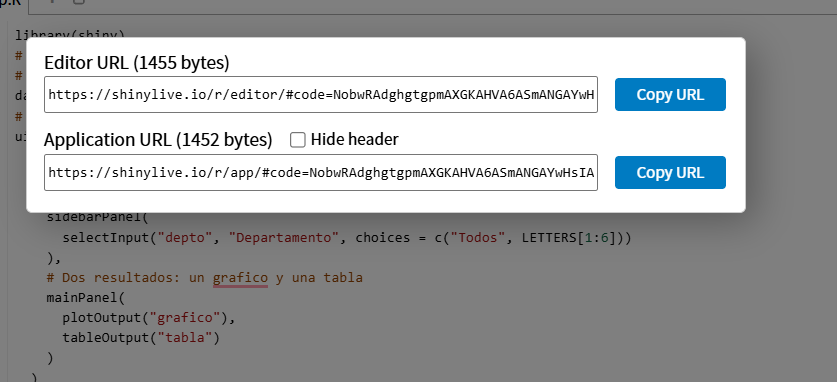

5. Pegue la dirección en otra pestaña.

**¿Cómo sé que funcionó?** La otra pestaña muestra su app, con su nombre en el título. Envíe esa dirección a alguien: le funciona sin instalar nada.

La dirección es larga porque **contiene** su app completa. Ya tiene algo para compartir: si un paso posterior falla, este enlace sigue funcionando.

## Paso 8 · Dígale a GitHub Pages que publique con Actions

El enlace del paso 7 es una copia suelta. Ahora la app se publicará desde su repositorio, en una dirección corta.

En el navegador, dentro de su repositorio `shiny-…`:

1. Entre a **Settings → Pages**.

[figure not shown]

2. En *Build and deployment*, en **Source**, cambie *Deploy from a branch* por **GitHub Actions**.

[figure not shown]

[figure not shown]

No hay botón para guardar: queda guardado al elegir.

**¿Cómo sé que funcionó?** En *Source* dice **GitHub Actions**.

**GitHub Actions** es un computador de GitHub que sigue una receta cada vez que hay un push. Con la misma idea se automatiza, por ejemplo, una extracción de datos de la web.